# Example of model simulation

Stem cell model

Author

Nicholas Harbour

Published

October 14, 2025, 13:58:28

Modified

October 14, 2025, 13:58:01

```python
import numpy as np
import matplotlib.pyplot as plt
```

This notebook is based on the paper: Michor, F., Hughes, T., Iwasa, Y. et al. Dynamics of chronic myeloid leukaemia. Nature 435, 1267–1270 (2005). https://doi.org/10.1038/nature03669

# 1 Model

## 1.1 Assumption / notation

denote $x_0, x_1, x_2, x_3$ the abundance of stem cells, progenitor cells, differentaited cells, and terminally differentiated cells (Healthy cells).

The respective Leukemic (cancer) abundances are denoted $y_0, y_1, y_2, y_3$ for cells without resistance mutations and $z_0, z_1, z_2, z_3$ for cancer cells with resistant (imatinib resistance) mutation.

- assume normal stem cells held constant by heomeostatic mechanism.
- Stem cells produce progenitor cells which produce differneated cells which produce terminally differentiated cells. The rate constants are given by $a,b,c$
- Assume thatBCR-ABL oncogene increases rate at which leukemic stem cells divide and differentiate into progenitors and BCR-ABL is thought to increase progenitor proliferatioin and differentiation. So we expect $a_y>a_x$ and $b_y>b_x$.
- Imatinib counteracts this effect reducing the rates to $\hat{a}_y < a_y$ and $\hat{b}_y < b_y$
- Death rates of stem, progenitor, differentaited and terminal cells denoted $d_0,d_1,d_2,d_3$.

## 1.2 Model equations

healthy cells
$$\begin{aligned}
\dot{x}_0 &= [\lambda(x_0) - d_0]x_0 \\
\dot{x}_1 &= a_x x_0 - d_1 x_1 \\
\dot{x}_2 &= b_x x_1 - d_2 x_2 \\
\dot{x}_3 &= c_x x_2 - d_3 x_3 \\
\end{aligned}$$

Sensitive cancer cells

$$\begin{aligned}
\dot{y}_0 &= [r_y(1 - u) - d_0]y_0 \\
\dot{y}_1 &= a_y y_0 - d_1 y_1 \\
\dot{y}_2 &= b_y y_1 - d_2 y_2 \\
\dot{y}_3 &= c_y y_2 - d_3 y_3 \\
\end{aligned}$$

Mutated / resistant cacer cells

$$\begin{aligned}
\dot{z}_0 &= [r_z - d_0]z_0 + r_y y_0 u \\
\dot{z}_1 &= a_z z_0 - d_1 z_1 \\
\dot{z}_2 &= b_z z_1 - d_2 z_2 \\
\dot{z}_3 &= c_z z_2 - d_3 z_3 \\
\end{aligned}$$

Homeostatis of normal stem cells is achived via approproate declining function $\lambda$.

# 2 Model simulation

```python
def stem_cell_model(IC,t,d_0,d_1,d_2,d_3,a_x,b_x,c_x,a_y,b_y,c_y,a_z,b_z,c_z,r_y,r_z,u,a_y_therapy,b_y_therapy,a_z_therapy,b_z_therapy,therapy):

    nt = len(t)
    dt = t[1] - t[0]
    print(therapy)

    x_0 = np.zeros(nt)
    x_1 = np.zeros(nt)
    x_2 = np.zeros(nt)
    x_3 = np.zeros(nt)

    y_0 = np.zeros(nt)
    y_1 = np.zeros(nt)
    y_2 = np.zeros(nt)
    y_3 = np.zeros(nt)

    z_0 = np.zeros(nt)
    z_1 = np.zeros(nt)
    z_2 = np.zeros(nt)
    z_3 = np.zeros(nt)

    # Set ICs
    x_0[0] = IC[0]
    x_1[0] = IC[1]
    x_2[0] = IC[2]
    x_3[0] = IC[3]

    y_0[0] = IC[4]
    y_1[0] = IC[5]
    y_2[0] = IC[6]
    y_3[0] = IC[7]

    z_0[0] = IC[8]
    z_1[0] = IC[9]
    z_2[0] = IC[10]
    z_3[0] = IC[11]

    # healthy cells remain at equilibrium
    for i in range(nt):
        x_0[i] = x_0[0]
        x_1[i] = a_x*x_0[0] / d_1
        x_2[i] = b_x *x_1[0] / d_2
        x_3[i] = c_x *x_2[0] / d_3


    for i in range(nt-1):

        if therapy[i] == 1:
            ay = a_y_therapy
            by = b_y_therapy
            az = a_z_therapy
            bz = b_z_therapy
        else:
            ay = a_y
            by = b_y


        # Cancer cells (sensirtive / no mutation)
        y_0[i+1] = y_0[i] + dt * ( (r_y*(1-u) - d_0)*y_0[i] )
        y_1[i+1] = y_1[i] + dt * ( ay*y_0[i] - d_1*y_1[i] )
        y_2[i+1] = y_2[i] + dt * ( by*y_1[i] - d_2*y_2[i] )
        y_3[i+1] = y_3[i] + dt * ( c_y*y_2[i] - d_3*y_3[i] )

        # Mutated cancer cells
        z_0[i+1] = z_0[i] + dt * ( (r_z -d_0)*z_0[i] + r_y*y_0[i]*u )
        z_1[i+1] = z_1[i] + dt * ( az*z_0[i] - d_1*z_1[i] )
        z_2[i+1] = z_2[i] + dt * ( bz*z_1[i] - d_2*z_2[i] )
        z_3[i+1] = z_3[i] + dt * ( c_z*z_2[i] - d_3*z_3[i] )


    return x_0, x_1, x_2, x_3, y_0, y_1, y_2, y_3, z_0, z_1, z_2, z_3
```

```python
# Parameter values taken from the figure 4
d_0 = 0.003
d_1 = 0.008
d_2 = 0.05
d_3 = 1

a_x = 0.8
b_x = 5
c_x = 100
r_y = 0.008
a_y = 2*a_x
b_y = 2*b_x
c_y = c_x
r_z = 0.023
a_z = a_y
b_z = b_y
c_z = c_y

# During therapy
a_y_therapy = a_y / 100.0
b_y_therapy = b_y / 750.0
a_z_therapy = a_y
b_z_therapy = b_y

# When considering resistant mutation we have
z_0 = 10
u = 4*10**-8

# Estimated ICs from the plot
IC = np.array([10**6,10**8,10**10,10**12,10**5.5,10**7.9,10**10,10**12,10,2500,10**6,10**8])
```

```python
t = np.linspace(0,500,1001)
therapy = np.ones(len(t))

# Simulate continous therapy
x_0,x_1,x_2,x_3, y_0, y_1, y_2, y_3, z_0, z_1, z_2, z_3 = stem_cell_model(IC,t,d_0,d_1,d_2,d_3,a_x,b_x,c_x,a_y,b_y,c_y,a_z,b_z,c_z,r_y,r_z,0,a_y_therapy,b_y_therapy,a_z_therapy,b_z_therapy,therapy)

# Simulate stop in therapy at time 400
for i in range(len(t)):
    if t[i] < 400:
        therapy[i] = 1
    else:
        therapy[i] = 0
xt_0,xt_1,xt_2,xt_3, yt_0, yt_1, yt_2, yt_3, zt_0, zt_1, zt_2, zt_3 = stem_cell_model(IC,t,d_0,d_1,d_2,d_3,a_x,b_x,c_x,a_y,b_y,c_y,a_z,b_z,c_z,r_y,r_z,0,a_y_therapy,b_y_therapy,a_z_therapy,b_z_therapy,therapy)

# Simulate model with resistant mutation rate
therapy = np.ones(len(t))
xr_0,xr_1,xr_2,xr_3, yr_0, yr_1, yr_2, yr_3, zr_0, zr_1, zr_2, zr_3 = stem_cell_model(IC,t,d_0,d_1,d_2,d_3,a_x,b_x,c_x,a_y,b_y,c_y,a_z,b_z,c_z,r_y,r_z,u,a_y_therapy,b_y_therapy,a_z_therapy,b_z_therapy,therapy)
```

```
[1. 1. 1. ... 1. 1. 1.]
[1. 1. 1. ... 0. 0. 0.]
[1. 1. 1. ... 1. 1. 1.]
```

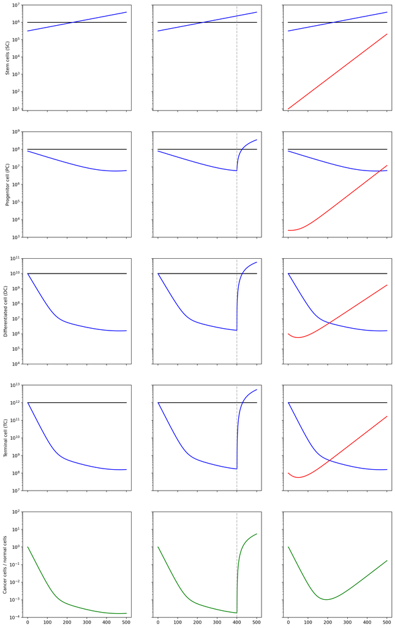

Black = healthy cells, Blue = Cancer (leukimic) cells no mutation, Red = Mutated / resistant cancer cells

```python
# make plot

fig,ax = plt.subplots(5,3, figsize = (15,25),sharey = 'row', sharex=True)


ax[0,0].plot(t,x_0, 'k')
ax[0,0].plot(t,y_0, 'b')
ax[0,0].set_yscale('log')
ax[0,0].set_ylim([8,10**7])
ax[0,0].set_ylabel("Stem cells (SC)")
#ax[0].plot(t,z_0)

ax[1,0].plot(t,x_1,'k')
ax[1,0].plot(t,y_1,'b')
ax[1,0].set_yscale('log')
ax[1,0].set_ylim([1000,10**9])
ax[1,0].set_ylabel("Progenitor cell (PC)")

ax[2,0].plot(t,x_2,'k')
ax[2,0].plot(t,y_2,'b')
ax[2,0].set_yscale('log')
ax[2,0].set_ylim([10**4,10**11])
ax[2,0].set_ylabel("Differentiated cell (DC)")

ax[3,0].plot(t,x_3,'k')
ax[3,0].plot(t,y_3,'b')
ax[3,0].set_yscale('log')
ax[3,0].set_ylim([10**7,10**13])
ax[3,0].set_ylabel("Terminal cell (TC)")

ax[4,0].plot(t, (y_0+y_1+y_2+y_3) / (x_0+x_1+x_2+x_3),'g')
ax[4,0].set_yscale('log')
ax[4,0].set_ylim([0.0001,100])
ax[4,0].set_ylabel("Cancer cells / normal cells")

ax[0,1].plot(t,xt_0, 'k')
ax[0,1].plot(t,yt_0, 'b')
ax[0,1].axvline(400,color = 'gray', alpha = 0.5,ls = '--')

ax[1,1].plot(t,xt_1, 'k')
ax[1,1].plot(t,yt_1, 'b')
ax[1,1].axvline(400,color = 'gray', alpha = 0.5,ls = '--')

ax[2,1].plot(t,xt_2, 'k')
ax[2,1].plot(t,yt_2, 'b')
ax[2,1].axvline(400,color = 'gray', alpha = 0.5, ls = '--')


ax[3,1].plot(t,xt_3, 'k')
ax[3,1].plot(t,yt_3, 'b')
ax[3,1].axvline(400,color = 'gray', alpha = 0.5, ls = '--')

ax[4,1].plot(t,  (yt_0 + yt_1 + yt_2 + yt_3) / (xt_0+xt_1+xt_2+xt_3), 'g')
ax[4,1].axvline(400,color = 'gray', alpha = 0.5, ls = '--')



ax[0,2].plot(t,xr_0, 'k')
ax[0,2].plot(t,yr_0, 'b')
ax[0,2].plot(t,zr_0,'r')

ax[1,2].plot(t,xr_1, 'k')
ax[1,2].plot(t,yr_1, 'b')
ax[1,2].plot(t,zr_1,'r')

ax[2,2].plot(t,xr_2, 'k')
ax[2,2].plot(t,yr_2, 'b')
ax[2,2].plot(t,zr_2,'r')


ax[3,2].plot(t,xr_3, 'k')
ax[3,2].plot(t,yr_3, 'b')
ax[3,2].plot(t,zr_3,'r')

ax[4,2].plot(t,  (yr_0 + yr_1 + yr_2 + yr_3 + z_0 + z_1 + z_2 + z_3) / (xt_0+xt_1+xt_2+xt_3), 'g')


plt.show()
```